# Short read Head 2 Head

Sam Lipworth

2023-07-21

## Introduction

The purpose of this work is to compare Illumina data from the Oxford Genomics Centre (OGC) to that from two external providers (ProviderX and Baseclear).

## Dataset and methods

Ten E. coli isolates were sequenced by all three companies.

Please note that I have subsampled to 100X maximum coverage to account for the fact that the total output by all three was different (and often very excessive).

I have then assembled using Shovill (Spades) and Skesa performing two independent assemblies with each assembler. There are therefore 10x2x3x2 = 120 assemblies in total.

All assemblers where run on default settings.

SNPs/Indels are calculated using pairwise comparisons with DNADiff.

## Analysis plan

1. Basic QC stats on reads
2. Comparison based on whole assembly metrics (N50/lenght/N contigs)
3. Assembly comparison between providers (SNPs/Indels)

## Basic QC stats on reads

First let’s compare basic quality metrics (%Q30 and %Q20 reads assessed using Seqkit stats).

```
## # A tibble: 60 × 17
##    file  format type  num_seqs sum_len min_len avg_len max_len    Q1    Q2    Q3
##    <chr> <chr>  <chr>    <dbl>   <dbl>   <dbl>   <dbl>   <dbl> <dbl> <dbl> <dbl>
##  1 07ad… FASTQ  DNA     828079  1.25e8       5    151      151   151   151   151
##  2 07ad… FASTQ  DNA     828079  1.25e8       5    151      151   151   151   151
##  3 15ac… FASTQ  DNA     828070  1.25e8       5    151      151   151   151   151
##  4 15ac… FASTQ  DNA     828070  1.25e8       5    151      151   151   151   151
##  5 15ba… FASTQ  DNA     828021  1.25e8       5    151      151   151   151   151
##  6 15ba… FASTQ  DNA     828021  1.25e8       5    151      151   151   151   151
##  7 38a8… FASTQ  DNA     828089  1.25e8       5    151.     151   151   151   151
##  8 38a8… FASTQ  DNA     828089  1.25e8       5    151      151   151   151   151
##  9 4333… FASTQ  DNA     828080  1.25e8       5    151      151   151   151   151
## 10 4333… FASTQ  DNA     828080  1.25e8       5    151      151   151   151   151
## # ℹ 50 more rows
## # ℹ 6 more variables: sum_gap <dbl>, N50 <dbl>, `Q20(%)` <dbl>, `Q30(%)` <dbl>,
## #   `GC(%)` <dbl>, provider <chr>
```

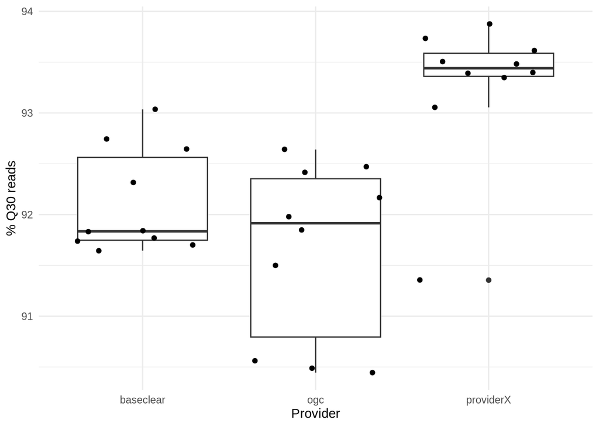

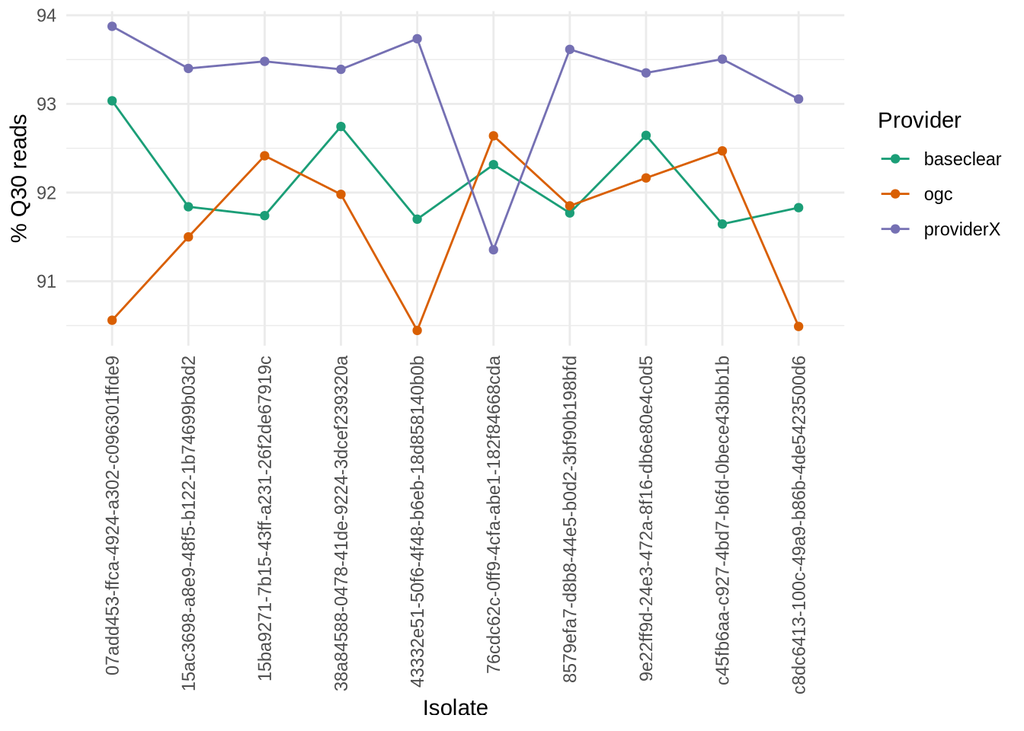

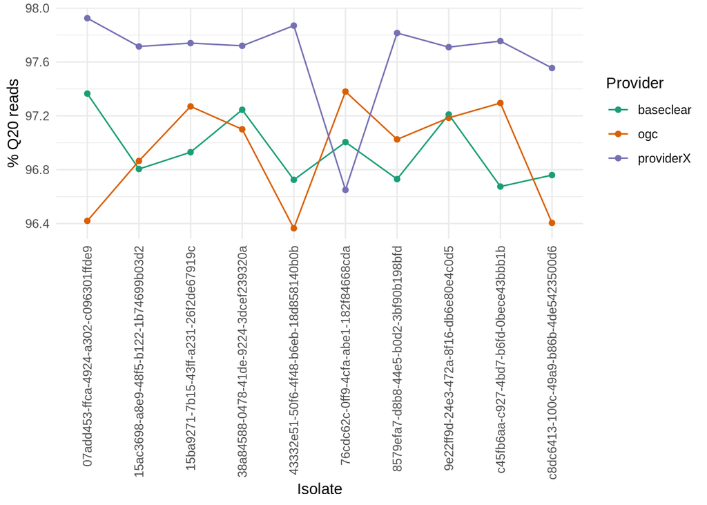

### Thoughts

Overall providerX seems to be the winner, OGC and Baseclear are very similar. Not that much in it though.

## Assembly stats

Finally let’s look at assembly statistics

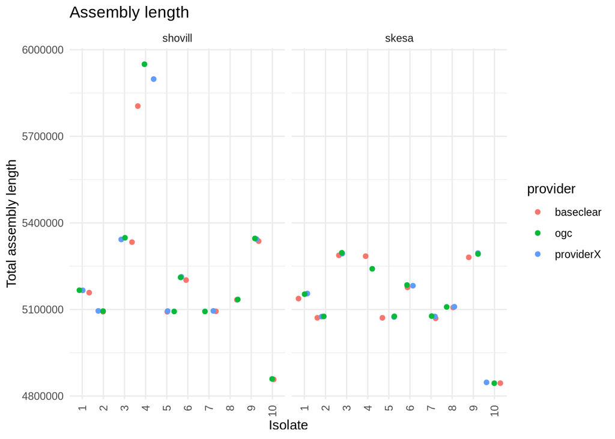

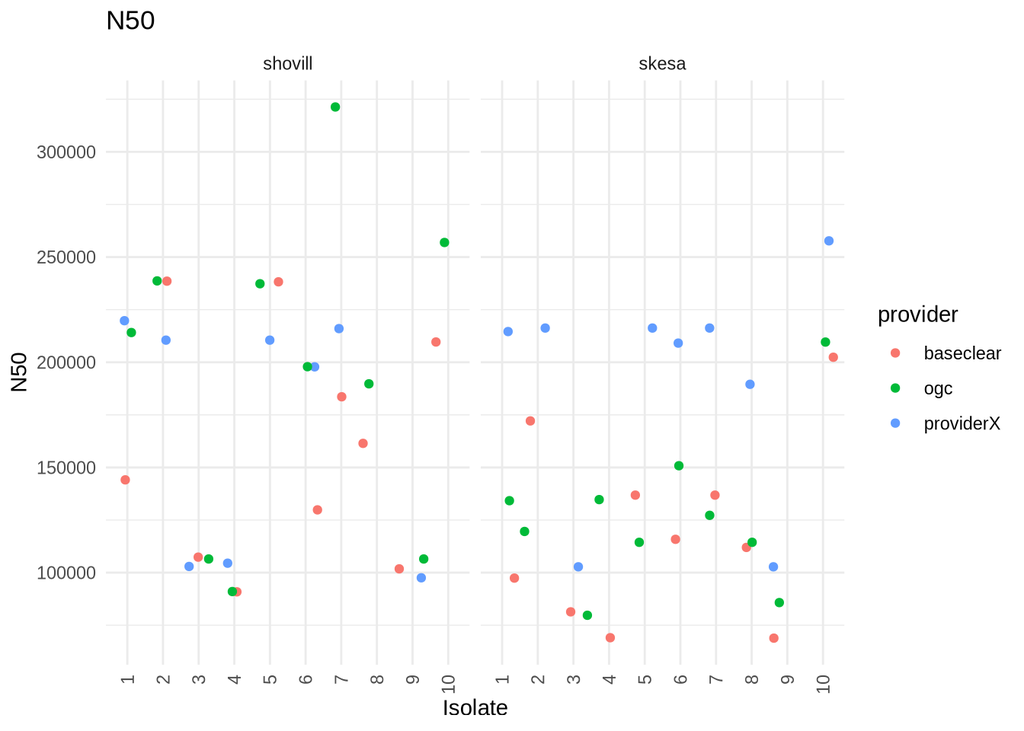

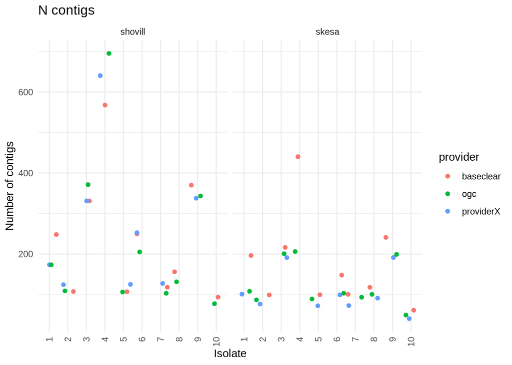

### Thoughts

Baseclear assemblies seem to be a bit worse, OGC and providerX very similar.

## Assembly comparison between providers

###SNPs

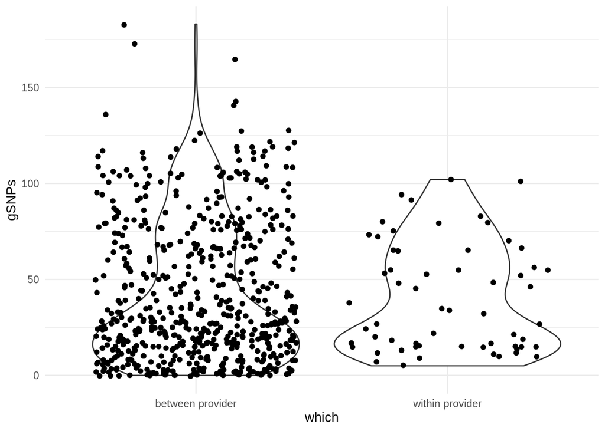

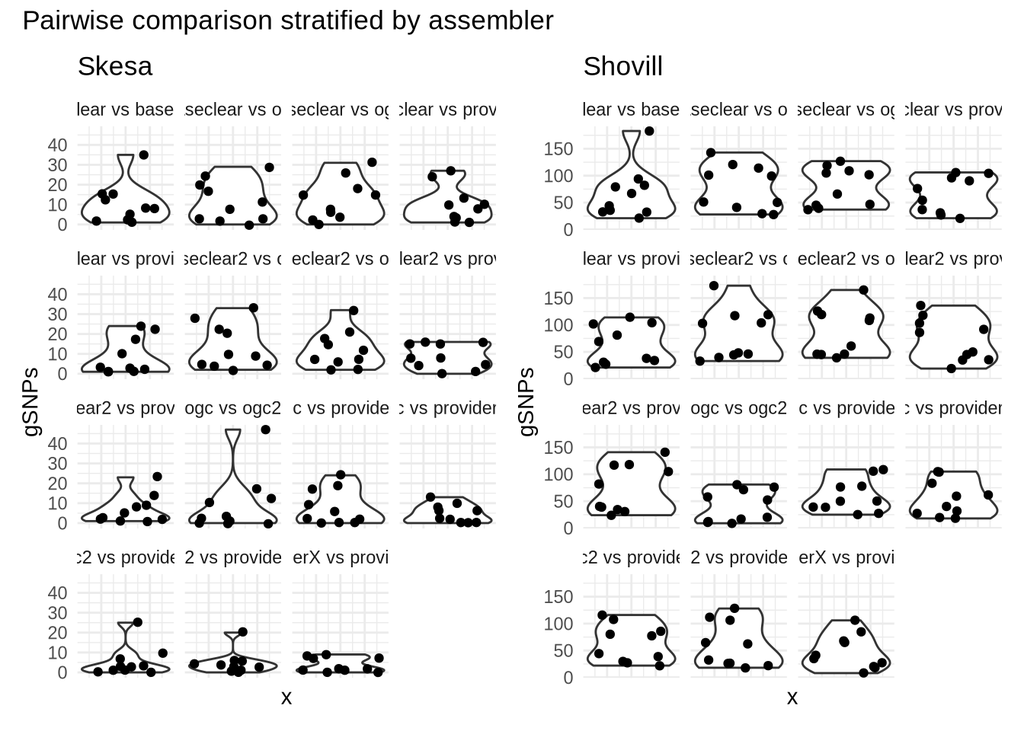

```
## # A tibble: 2 × 4
##   which            median    q1    q3
##   <chr>             <dbl> <dbl> <dbl>
## 1 between provider     30  14.8    68
## 2 within provider      33  15      65
```

```
##
##  Kruskal-Wallis rank sum test
##
## data:  comparison$gSNPs by comparison$which
## Kruskal-Wallis chi-squared = 0.017263, df = 1, p-value = 0.8955
```

### Indels

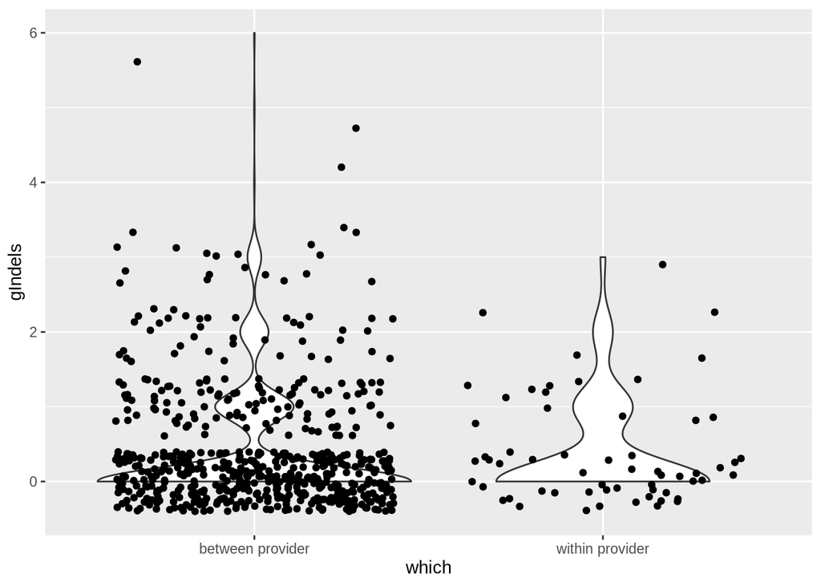

```
## # A tibble: 2 × 4
##   which            median    q1    q3
##   <chr>             <dbl> <dbl> <dbl>
## 1 between provider      0     0     1
## 2 within provider       0     0     1
```

```
##
##  Kruskal-Wallis rank sum test
##
## data:  comparison$gIndels by comparison$which
## Kruskal-Wallis chi-squared = 0.0068483, df = 1, p-value = 0.934
```

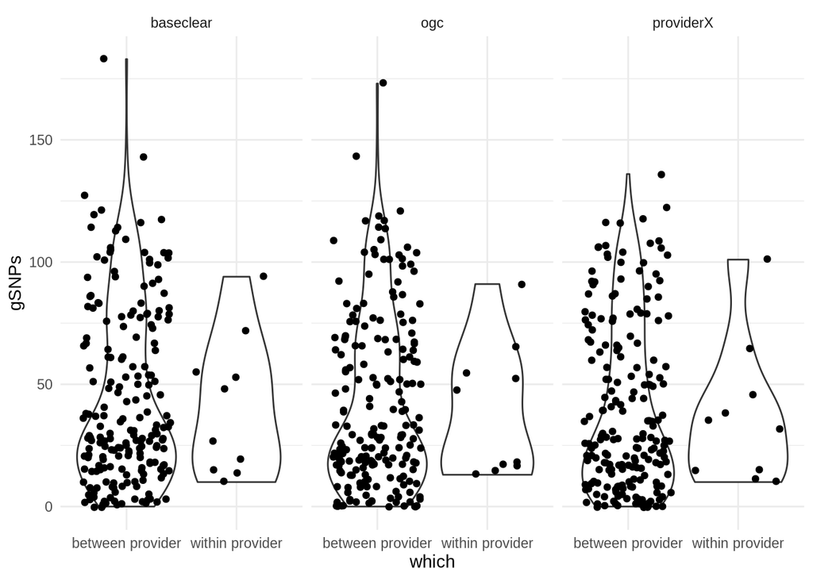

```
## # A tibble: 3 × 4
##   provider  median    q1    q3
##   <chr>      <dbl> <dbl> <dbl>
## 1 baseclear   31    16      74
## 2 ogc         29    15.8    67
## 3 providerX   27.5  10      66
```

### Consider OGC as the “Truth”

The problem with this dataset is that we don’t know what the truth is (there are no available reference assemblies.) But we know that we trust OGC data, so lets directly compare the two new external providers to this data.

```r
ogc_comparison<-filter(comparison, provider1=='ogc'| provider2=='ogc')
ogc_comparison<-filter(ogc_comparison, !provider1==provider2)

baseclear_ogc_comparison <-filter(ogc_comparison,provider1=='baseclear' | provider2=='baseclear')
baseclear_ogc_comparison$Qscore<- -10 * log10(baseclear_ogc_comparison$gSNPs/5e6)
median(baseclear_ogc_comparison$Qscore)
```

```
## [1] 51.80456
```

```r
providerX_ogc_comparison <-filter(ogc_comparison,provider1=='providerX' | provider2=='providerX')
providerX_ogc_comparison$Qscore<- -10 * log10(providerX_ogc_comparison$gSNPs/5e6)
median(providerX_ogc_comparison$Qscore)
```

```
## [1] 52.75801
```

```r
ogc_ogc_comparison<-filter(comparison, provider1=='ogc'& provider2=='ogc')
ogc_ogc_comparison$Qscore<- -10 * log10(ogc_ogc_comparison$gSNPs/5e6)
median(ogc_ogc_comparison$Qscore)
```

```
## [1] 52.30713
```

So if OGC is the truth, the Q score of Baseclear data is 52 and of providerX data is 53. The median Q score of OGC data with itself (when considering different independent assemblies/assemblers) is 52.

## Conclusion

I think the conclusion is that providerX data seems to be the highest quality and Baseclear the lowest but this is pretty marginal and all providers produce high quality and comparable data.